# WCGNA on microbiome tutorial

Comparacion de Pacientes con EPOC vs Controles

2022-06-22

## 0.1 Pre-WGCNA Data preparation

Read in raw abundance values of OTUs Note: OTUs represent 16S rRNA sequences that were assessed with the universal primers 515F-Y (5’-GTGYCAGCMGCCGCGGTAA) and 926R (5’-CCGYCAATTYMTTTRAGTTT) and were created using a 97% similarity cutoff Note: These populations have been previously subsampled to the smallest library size Note: All of the above processing took place in mothur

```r
data<-read.table("MB.0.03.subsample.fn.txt",header=T,na.strings="NA")
```

Get rid of first three columns since the OTUs don’t actually start until the 4th column

```r
data1 = data[-1][-1][-1]
```

You should turn your raw abundance values into a relative abundance matrix and transform it I recommend a Hellinger Transformation (a square root of the relative abundance). This effectively gives low weight to variables with low counts and many zeros It would also also be possible to do the Logarithmic transformation of Anderson et al. (2006): log_b(x)+1 for X>0 and zeros are left as zeros

```r
library("vegan")
HellingerData<-decostand(data1,method = "hellinger")
#AndersonData<-decostand(data1,method = "log", logbase=2)
```

You have to limit the OTUs to the most frequent ones (ones that occur in multiple samples so that you can measure co-occurance across samples) I just looked at my data file and looked for where zeros became extremely common. This was easy because mothur sorts the OTUs according to abundance If you would like a more objective way of selecting the OTUs or if your OTUs are not sorted you then this code may help:

```r
lessdata <- data1[,colSums(data1) > 0.05] ## Though you will have to decide what cutoff works best for your data
```

You also have to reattach Group Name column

```r
RelAbun1 = data.frame(data[2],HellingerData[1:750])
RelAbun1[1:6,1:6]
```

```
##   Group  Otu00001   Otu00002   Otu00003  Otu00004  Otu00005
## 1 M1401 0.2203850 0.40735095 0.23864778 0.1703193 0.4692827
## 2 M1402 0.2627963 0.23668817 0.27126769 0.2004652 0.4458726
## 3 M1403 0.1651629 0.48736531 0.30388918 0.2468700 0.2897678
## 4 M1404 0.0000000 0.07564317 0.05158822 0.3049819 0.6509116
## 5 M1405 0.0000000 0.08074833 0.04159175 0.2579411 0.5240713
## 6 M1406 0.1147765 0.28676738 0.15476465 0.1237042 0.4163971
```

Write file

```r
write.table(RelAbun1, file = "MontereyRelAbun.txt", sep="\t")
```

## 0.2 WGCNA: Weighted Gene Correlation Network Analysis

There is a lot of great documentation online by the authors (https://horvath.genetics.ucla.edu/html/CoexpressionNetwork/Rpackages/WGCNA/Tutorials/) The following shows my application of it to 16S rRNA abundance data I had

```r
library("WGCNA")
```

Note: If you see gene is written it actually means taxon or OTU

### 0.2.1 Start and visualizing data

Bring data in:

```r
OTUs<-read.table("MontereyRelAbun.txt",header=T,sep="\t")
dim(OTUs);
```

```
## [1]  47 751
```

```r
library(dplyr)
names(OTUs) %>% tail(10);
```

```
##  [1] "Otu00741" "Otu00742" "Otu00743" "Otu00744" "Otu00745" "Otu00746"
##  [7] "Otu00747" "Otu00748" "Otu00749" "Otu00750"
```

Turn the first column (sample name) into row names (so that only OTUs make up actual columns):

```r
datExpr0 = as.data.frame((OTUs[,-c(1)]));
names(datExpr0) = names(OTUs)[-c(1)];
rownames(datExpr0) = OTUs$Group;
```

Check Data for excessive missingness:

```r
gsg = goodSamplesGenes(datExpr0[-1], verbose = 3);
```

```
##  Flagging genes and samples with too many missing values...
##   ..step 1
```

```r
gsg$allOK
```

```
## [1] TRUE
```

TRUE if all OTUs have passed the cut This means that when you limited your OTUs to the most common OTUs above that you didn’t leave any in that had too many zeros It is still possible that you were too choosy though. If you got FALSE here then follow the steps below:

```r
## Did not need to do following step with Monterey

## If false then remove the offenders:
#if (!gsg$allOK)
#{
#  # Optionally, print the OTU and sample names that were removed:
#  if (sum(!gsg$goodGenes)>0)
#    printFlush(paste("Removing genes:", paste(names(datExpr0)[!gsg$goodGenes], collapse = ", ")));
#  if (sum(!gsg$goodSamples)>0)
#    printFlush(paste("Removing samples:", paste(rownames(datExpr0)[!gsg$goodSamples], collapse = ", ")));
#  # Remove the offending genes and samples from the data:
#  datExpr0 = datExpr0[gsg$goodSamples, gsg$goodGenes]
#}
```

Cluster the samples to see if there are any obvious outliers

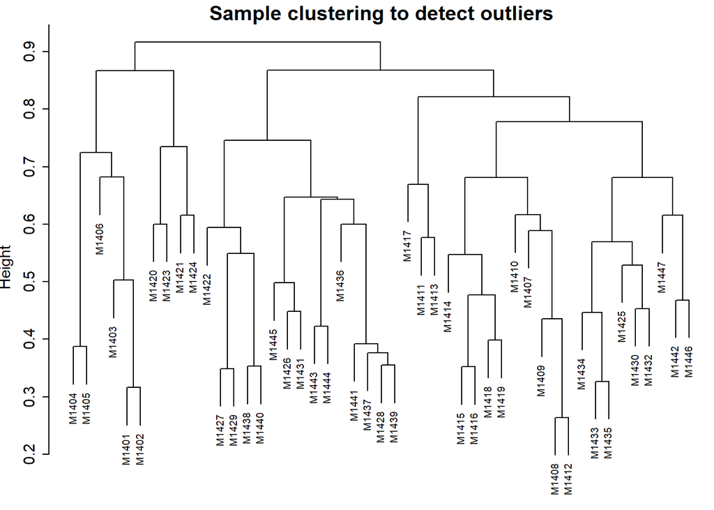

```r
sampleTree = hclust(dist(datExpr0), method = "average"); # que distancia usa???


par(cex = 0.6);
par(mar = c(0,4,2,0))

plot(sampleTree, main = "Sample clustering to detect outliers", sub="", xlab="", cex.lab = 1.5,
     cex.axis = 1.5, cex.main = 2)
```

The sample dendrogram doesn’t show any obvious outliers so I didn’t remove any samples. If you need to remove some samples the code is below.

```r
## No outliers for Monterey so didn't have to do

## Can remove outlier by changing height cut (could also go in and remove it mannually)
## Plot a line to show the cut:
#abline(h = 15, col = "red");

## Determine cluster under the line:
#clust = cutreeStatic(sampleTree, cutHeight = 15, minSize = 10)
#table(clust)

## clust 1 contains the samples we want to keep:
#keepSamples = (clust==1)
#datExpr = datExpr0[keepSamples, ]
#nTaxa = ncol(datExpr)
#nSamples = nrow(datExpr)

## Note: in subsequent analyses you will have to change datExpr0 to datExpr
```

Now read in trait (Environmental) data and match with expression samples:

```r
traitData = read.csv("OxygenMatrixMonterey.csv");
dim(traitData)
```

```
## [1] 47 14
```

```r
names(traitData)
```

```
##  [1] "Sample"          "Date"            "Location"        "Depth"
##  [5] "Zone"            "UpwellingS"      "UpwellingN"      "UpwellingAvg"
##  [9] "PreUpwellingS"   "PreUpwellingN"   "PreUpwellingAvg" "CR"
## [13] "OxygenConc"      "Temp"
```

Form a data frame analogous to expression data (relative abundances of OTUs) that will hold the Environmental traits: Note: used datExpr0 rather than datExpr because we did not have to ditch any samples above:

```r
OTUSamples = rownames(datExpr0);
traitRows = match(OTUSamples, traitData$Sample);
datTraits = traitData[traitRows, -1];
rownames(datTraits) = traitData[traitRows, 1];
collectGarbage() # Performs garbage collection until free memory idicators show no change


head(datTraits)
```

```
##            Date Location Depth    Zone UpwellingS UpwellingN UpwellingAvg
## M1401 6/18/2014     100m     3  Thermo        109        193          151
## M1402 6/18/2014     100m     4  Thermo        109        193          151
## M1403 6/18/2014   ProOff     9  Thermo        109        193          151
## M1404 6/18/2014   ProOff     1 Surface        109        193          151
## M1405 6/18/2014     100m     8    Deep        109        193          151
## M1406 6/18/2014     100m     1 Surface        109        193          151
##       PreUpwellingS PreUpwellingN PreUpwellingAvg CR OxygenConc Temp
## M1401      257.6667      261.3333           259.5 NA   358.4375 14.7
## M1402      257.6667      261.3333           259.5 NA   343.4375 14.3
## M1403      257.6667      261.3333           259.5 NA   353.1250 13.7
## M1404      257.6667      261.3333           259.5 NA   369.3750   NA
## M1405      257.6667      261.3333           259.5 NA   312.8125 13.9
## M1406      257.6667      261.3333           259.5 NA   385.3125 15.3
```

```r
head(datExpr0,10)[1:10,1:10]
```

```
##        Otu00001   Otu00002   Otu00003  Otu00004   Otu00005   Otu00006
## M1401 0.2203850 0.40735095 0.23864778 0.1703193 0.46928266 0.13746106
## M1402 0.2627963 0.23668817 0.27126769 0.2004652 0.44587262 0.16795906
## M1403 0.1651629 0.48736531 0.30388918 0.2468700 0.28976784 0.17456342
## M1404 0.0000000 0.07564317 0.05158822 0.3049819 0.65091164 0.23099772
## M1405 0.0000000 0.08074833 0.04159175 0.2579411 0.52407127 0.22158925
## M1406 0.1147765 0.28676738 0.15476465 0.1237042 0.41639712 0.09719965
## M1407 0.2460601 0.09719965 0.05410618 0.3129496 0.19576351 0.29341860
## M1408 0.2985884 0.10697560 0.30058714 0.2574247 0.03460643 0.26254297
## M1409 0.3178018 0.08785157 0.39943406 0.2145723 0.01631363 0.28256029
## M1410 0.3169633 0.10572438 0.06212044 0.1495169 0.01631363 0.22868190
##         Otu00007   Otu00008   Otu00009   Otu00010
## M1401 0.13842571 0.00000000 0.04756198 0.17109875
## M1402 0.18636131 0.00000000 0.04756198 0.25061468
## M1403 0.19879879 0.00000000 0.05028197 0.15647481
## M1404 0.03052000 0.01153548 0.07203902 0.01631363
## M1405 0.16795906 0.00000000 0.06212044 0.15900556
## M1406 0.09990015 0.06726280 0.27588845 0.09923191
## M1407 0.28279566 0.01153548 0.05994009 0.28350060
## M1408 0.35102739 0.01998003 0.06212044 0.27322280
## M1409 0.27948246 0.01998003 0.03052000 0.26756336
## M1410 0.36787137 0.04159175 0.01153548 0.33452879
```

Now expression data (relative abundances of OTUs) is in the variable datExpr0 and the corresponding Environmental traits in the variable datTraits

#### 0.2.1.1 Visualize how Environmental traits relate to clustered samples (visualized with the dendogram from above)

Again, used datExpr0 for this because we did not need to do certain above steps. Can use any of the datTraits for this step

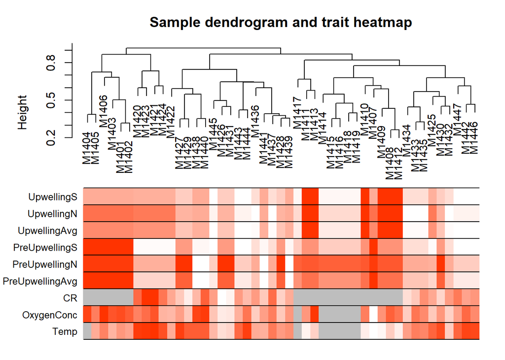

```r
#Re-cluster samples:
sampleTree2 = hclust(dist(datExpr0), method = "average")
## Convert traits to a color representation: white means low, red means high, grey means missing entry:
traitColors = numbers2colors(datTraits[5:13], signed = FALSE);
## Plot the sample dendrogram and the colors underneath:
plotDendroAndColors(sampleTree2, traitColors,
                    groupLabels = names(datTraits[5:13]),
                    main = "Sample dendrogram and trait heatmap")
```

White means a low value and red means a high value. Gray means missing entry.

Can also visualze just one trait with the dendrogram:

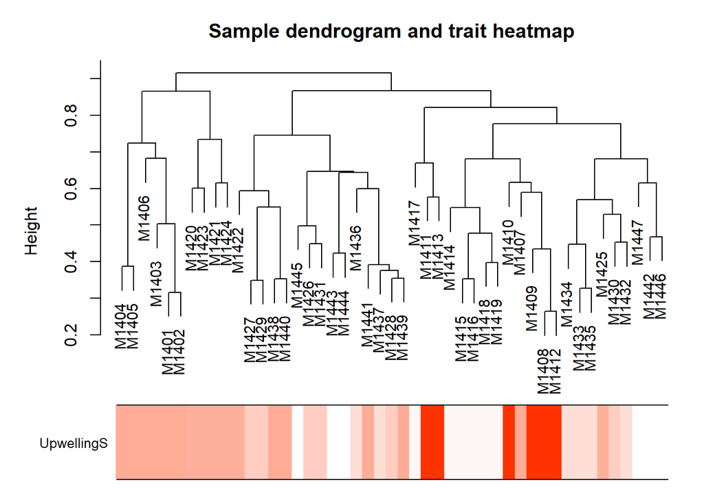

```r
traitColors = numbers2colors(datTraits$UpwellingS, signed= FALSE);
plotDendroAndColors(sampleTree2, traitColors,
                    groupLabels = names(datTraits[5:13]),
                    main = "Sample dendrogram and trait heatmap")
```

```r
# Save
save(datExpr0, datTraits, file = "Monterey-dataInput.RData")
```

## 0.3 Start of network analysis

Do this first no matter what way network is made The following setting is important, do not omit.

```r
options(stringsAsFactors = FALSE);
```

Allows multi-threading within WGCNA. This helps speed up certain calculations. At present this call is necessary for the code to work. Any error here may be ignored but you may want to update WGCNA if you see one.

```r
enableWGCNAThreads()
```

```
## Allowing parallel execution with up to 7 working processes.
```

Load the data saved in the first part

```r
lnames = load(file = "Monterey-dataInput.RData");
```

The variable lnames contains the names of loaded variables.

```r
lnames
```

```
## [1] "datExpr0"  "datTraits"
```

### 0.3.1 Network construction

```r
## 2a--I did NOT do this method of creating the network for Monterey
## This is a one step method of network construction (minimal efforts but the values may not be optimized)
## For details visit the code can be found: https://horvath.genetics.ucla.edu/html/CoexpressionNetwork/Rpackages/WGCNA/Tutorials/Consensus-NetworkConstruction-blockwise.pdf
```

The following sections provide a step by step construction of the network and module detection:

#### 0.3.1.1 Choosing soft-thresholding power: analysis of network topology

Choose a set of soft-thresholding powers:

```r
powers = c(c(1:10), seq(from = 11, to=30, by=1))
powers
```

```
##  [1]  1  2  3  4  5  6  7  8  9 10 11 12 13 14 15 16 17 18 19 20 21 22 23 24 25
## [26] 26 27 28 29 30
```

Call the network topology analysis function

Note: using a signed network because it preserves the sign of the connection (whether nodes are positively or negatively correlated); this is recommendation by authors of WGCNA:

```r
sft = pickSoftThreshold(datExpr0, powerVector = powers, verbose = 5, networkType = "signed")
```

```
## pickSoftThreshold: will use block size 750.
##  pickSoftThreshold: calculating connectivity for given powers...
##    ..working on genes 1 through 750 of 750
##    Power SFT.R.sq slope truncated.R.sq  mean.k. median.k. max.k.
## 1      1   0.0299  1.47          0.852 399.0000  400.0000 464.00
## 2      2   0.1300 -1.74          0.915 221.0000  221.0000 305.00
## 3      3   0.3480 -2.34          0.931 128.0000  125.0000 210.00
## 4      4   0.4640 -2.41          0.949  76.3000   73.1000 150.00
## 5      5   0.5990 -2.57          0.966  47.2000   44.0000 111.00
## 6      6   0.7010 -2.52          0.976  30.1000   27.1000  83.40
## 7      7   0.7660 -2.47          0.992  19.8000   17.2000  64.30
## 8      8   0.8130 -2.42          0.986  13.3000   11.0000  50.30
## 9      9   0.8390 -2.34          0.991   9.2200    7.1900  40.00
## 10    10   0.8610 -2.24          0.992   6.5200    4.8800  32.20
## 11    11   0.8670 -2.19          0.987   4.7000    3.3700  26.20
```

[output cut: 19 more lines]

Plot the results:

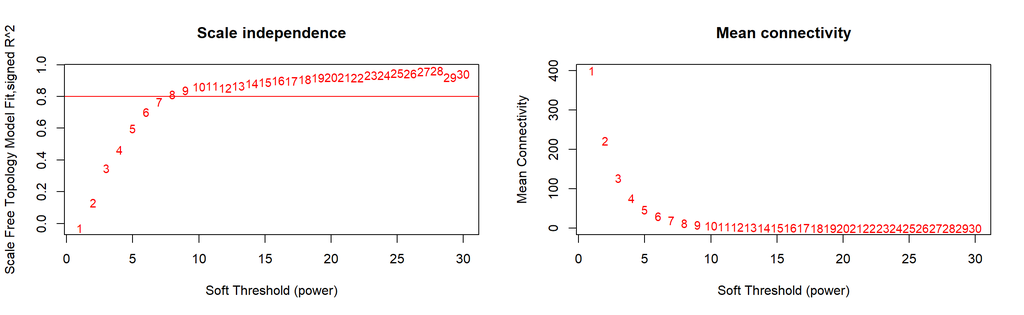

```r
par(mfrow = c(1,2));
cex1 = 0.9;

## Scale-free topology fit index as a function of the soft-thresholding power:
plot(sft$fitIndices[,1], -sign(sft$fitIndices[,3])*sft$fitIndices[,2],
     xlab="Soft Threshold (power)",ylab="Scale Free Topology Model Fit,signed R^2",type="n",
     main = paste("Scale independence"));
text(sft$fitIndices[,1], -sign(sft$fitIndices[,3])*sft$fitIndices[,2],
     labels=powers,cex=cex1,col="red");

## This line corresponds to using an R^2 cut-off of h:
abline(h=0.8,col="red")

## Mean connectivity as a function of the soft-thresholding power:
plot(sft$fitIndices[,1], sft$fitIndices[,5],
     xlab="Soft Threshold (power)",ylab="Mean Connectivity", type="n",
     main = paste("Mean connectivity"))
text(sft$fitIndices[,1], sft$fitIndices[,5], labels=powers, cex=cex1,col="red")
```

#### 0.3.1.2 Calculate the adjacencies, using the soft thresholding power of 10:

Note: Have to specify signed network again:

```r
softPower = 10;
adjacency = adjacency(datExpr0, power = softPower, type = "signed");
adjacency[1:5,1:5]
```

```
##              Otu00001     Otu00002     Otu00003     Otu00004     Otu00005
## Otu00001 1.000000e+00 2.882442e-05 2.231191e-02 5.428889e-02 9.843431e-05
## Otu00002 2.882442e-05 1.000000e+00 8.632641e-03 1.890446e-05 5.338458e-05
## Otu00003 2.231191e-02 8.632641e-03 1.000000e+00 3.082413e-03 5.630832e-05
## Otu00004 5.428889e-02 1.890446e-05 3.082413e-03 1.000000e+00 8.078048e-04
## Otu00005 9.843431e-05 5.338458e-05 5.630832e-05 8.078048e-04 1.000000e+00
```

#### 0.3.1.3 Transform adjacency into Topological Overlap Matrix and calculate corresponding dissimilarity

Note: The TOM you calculate shows the topological similarity of nodes, factoring in the connection strength two nodes share with other “third party” nodes  
This will minimize effects of noise and spurious associations:

Turn adjacency into topological overlap: Note: Have to specify signed network again:

```r
TOM = TOMsimilarity(adjacency, TOMType = "signed");
```

```
## ..connectivity..
## ..matrix multiplication (system BLAS)..
## ..normalization..
## ..done.
```

```r
TOM[1:5, 1:5]
```

```
##             [,1]         [,2]        [,3]         [,4]         [,5]
## [1,] 1.000000000 0.0007241070 0.013645540 0.0262171567 0.0017026423
## [2,] 0.000724107 1.0000000000 0.005778747 0.0007648648 0.0005041321
## [3,] 0.013645540 0.0057787466 1.000000000 0.0046199252 0.0010126789
## [4,] 0.026217157 0.0007648648 0.004619925 1.0000000000 0.0029863046
## [5,] 0.001702642 0.0005041321 0.001012679 0.0029863046 1.0000000000
```

```r
dissTOM = 1-TOM
```

#### 0.3.1.4 Create a dendogram using a hierarchical clustering tree

Call the hierarchical clustering function

```r
TaxaTree = hclust(as.dist(dissTOM), method = "average");
```

Plot the resulting clustering tree (dendrogram)

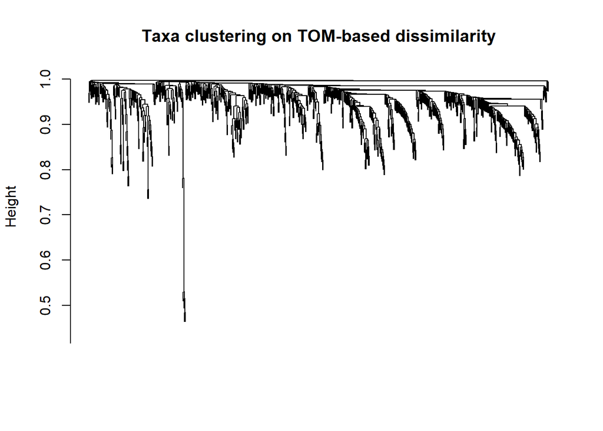

```r
plot(TaxaTree, xlab="", sub="", main = "Taxa clustering on TOM-based dissimilarity",
     labels = FALSE, hang = 0.04);
```

You have to decide the optimal module size for your system and should play around with this value a little I wanted relatively large module so I set the minimum module size relatively high (30):

```r
minModuleSize = 30;

## Module identification using dynamic tree cut:
dynamicMods = cutreeDynamic(dendro = TaxaTree, distM = dissTOM,
                            deepSplit = 2, pamRespectsDendro = FALSE,
                            minClusterSize = minModuleSize);
```

```
##  ..cutHeight not given, setting it to 0.995  ===>  99% of the (truncated) height range in dendro.
##  ..done.
```

```r
table(dynamicMods)
```

```
## dynamicMods
##   1   2   3   4   5   6   7
## 216 135 113 102  71  64  49
```

#### 0.3.1.5 Convert numeric lables into colors

```r
dynamicColors = labels2colors(dynamicMods)
table(dynamicColors)
```

```
## dynamicColors
##     black      blue     brown     green       red turquoise    yellow
##        49       135       113        71        64       216       102
```

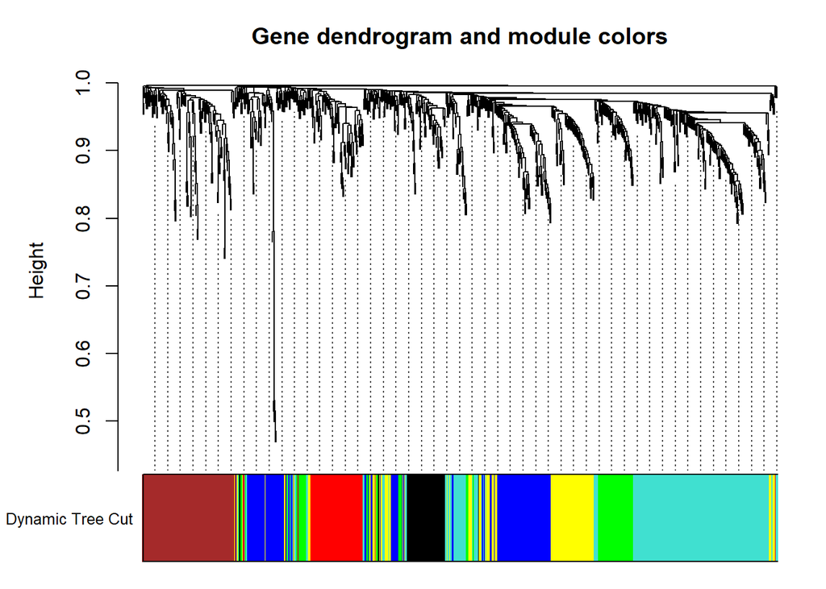

```r
## Plot the dendrogram with module colors underneath
plotDendroAndColors(TaxaTree, dynamicColors, "Dynamic Tree Cut",
                    dendroLabels = FALSE, hang = 0.03,
                    addGuide = TRUE, guideHang = 0.05,
                    main = "Gene dendrogram and module colors")
```

### 0.3.2 Analyze network

#### 0.3.2.1 Visualize similarity of the modules and cluster them

Quatify co-expression similarity of the entire modules using eigengenes and cluster them based on their correlation. Note: An eigengene is 1st principal component of a module expression matrix and represents a suitably defined average OTU community

```r
## Calculate eigengenes
MEList = moduleEigengenes(datExpr0, colors = dynamicColors)
MEs = MEList$eigengenes
MEs[1:5, 1:5]
```

```
##           MEblack        MEblue     MEbrown     MEgreen      MEred
## M1401 -0.11555754 -0.0922943764 -0.01344478 -0.09448880 -0.1259087
## M1402 -0.09838209 -0.0996721266  0.02235384 -0.05801773 -0.1253426
## M1403 -0.10149053 -0.0807281889  0.05729431 -0.12857647 -0.1203714
## M1404 -0.11049961 -0.0009450585  0.11334418 -0.09243175 -0.1268049
## M1405 -0.13100735 -0.0226425270  0.16598308  0.01389766 -0.1148762
```

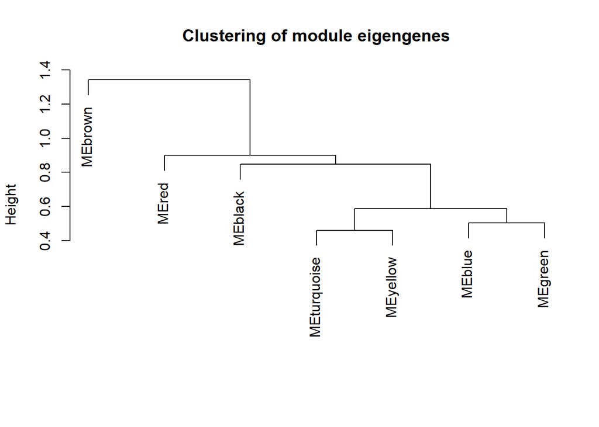

```r
## Calculate dissimilarity of module eigengenes
MEDiss = 1-cor(MEs);

## Cluster module eigengenes
METree = hclust(as.dist(MEDiss), method = "average");
## Plot the result
plot(METree, main = "Clustering of module eigengenes",
     xlab = "", sub = "")
```

#### Merge modules based on similaarity

We can merge the different modules according to their similarity. For example, here we shose a height cut of 0.30, corresponding to a similarity of 0.70 to merge, so nothing got merged

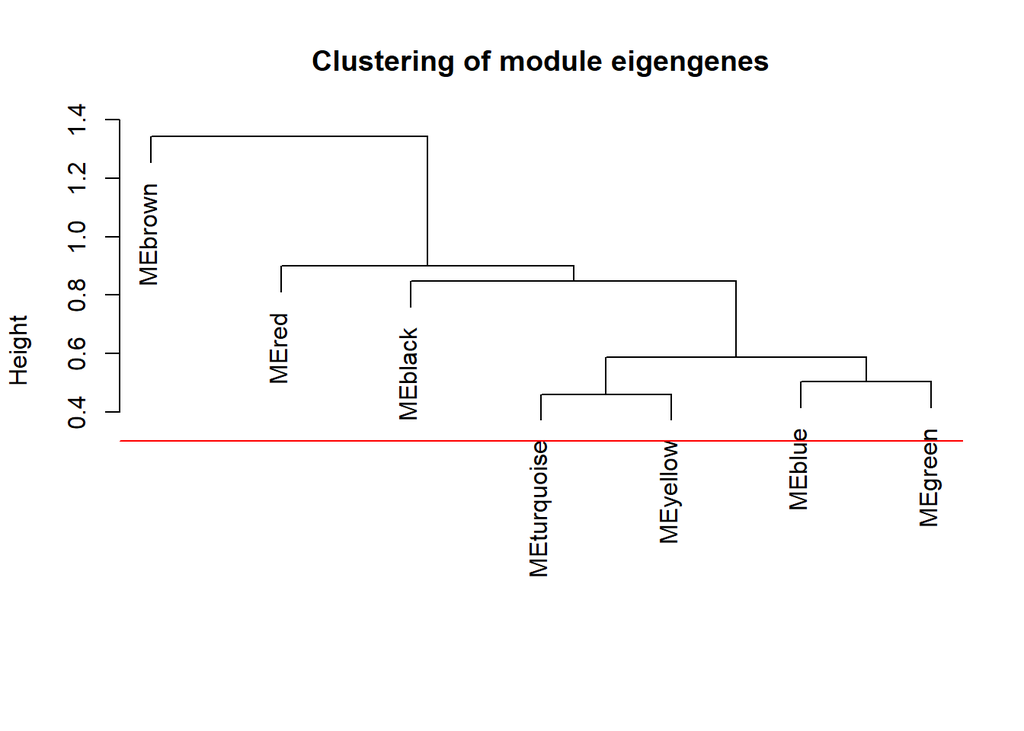

```r
MEDissThres = 0.30


plot(METree, main = "Clustering of module eigengenes",
     xlab = "", sub = "")
## Plot the cut line into the dendrogram
abline(h=MEDissThres, col = "red")
```

```r
## Call an automatic merging function
merge = mergeCloseModules(datExpr0, dynamicColors, cutHeight = MEDissThres, verbose = 3)
```

```
##  mergeCloseModules: Merging modules whose distance is less than 0.3
##    multiSetMEs: Calculating module MEs.
##      Working on set 1 ...
##      moduleEigengenes: Calculating 7 module eigengenes in given set.
##    Calculating new MEs...
##    multiSetMEs: Calculating module MEs.
##      Working on set 1 ...
##      moduleEigengenes: Calculating 7 module eigengenes in given set.
```

```r
## The merged module colors
mergedColors = merge$colors;

## Eigengenes of the new merged modules:
mergedMEs = merge$newMEs;
```

If you had combined different modules then that would show in this plot:

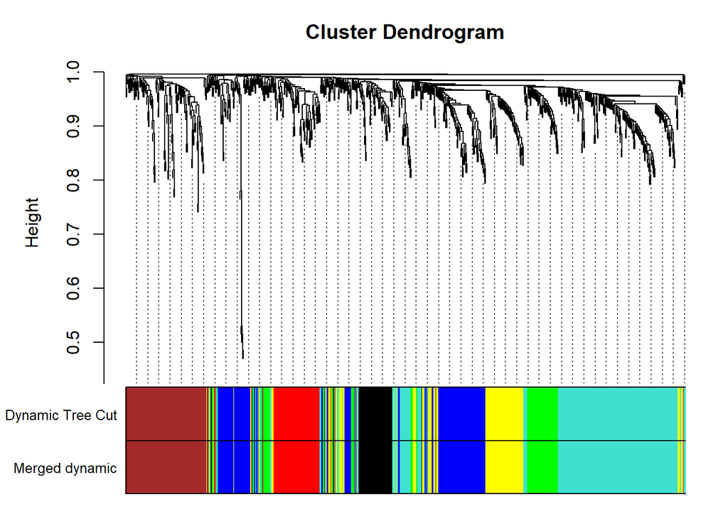

```r
plotDendroAndColors(TaxaTree,
                    cbind(dynamicColors, mergedColors),
                    c("Dynamic Tree Cut", "Merged dynamic"),
                    dendroLabels = FALSE, hang = 0.03,
                    addGuide = TRUE, guideHang = 0.05)
```

```r
## Rename to moduleColors
moduleColors = mergedColors

## Construct numerical labels corresponding to the colors
colorOrder = c("grey", standardColors(50));
moduleLabels = match(moduleColors, colorOrder)-1;
MEs = mergedMEs;

## Save module colors and labels for use in subsequent parts
save(MEs, moduleLabels, moduleColors, TaxaTree, file = "Monterey-networkConstruction-stepByStep.RData")
```

#### 0.3.2.2 Extra Visualization

Can due after modules are assigned

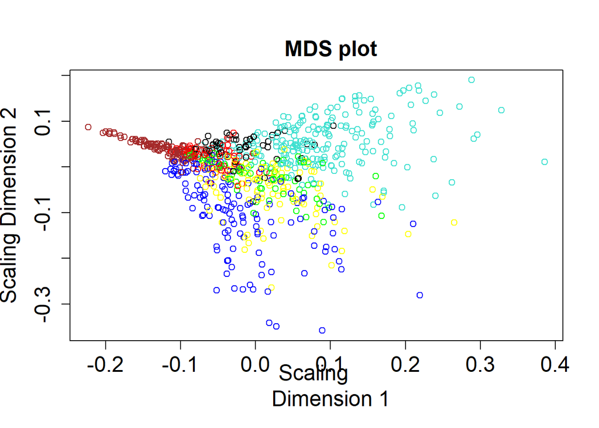

```r
cmd1=cmdscale(as.dist(dissTOM),2)
par(mfrow=c(1,1))
plot(cmd1, col=as.character(dynamicColors),  main="
     MDS plot",xlab="Scaling
     Dimension 1",ylab="Scaling Dimension 2",
     cex.axis=1.5,cex.lab=1.5, cex.main=1.5)

## Vs. your merged modules (this will look identical to the first MDS plot since we didn't merge any modules):
cmd1=cmdscale(as.dist(dissTOM),2)
par(mfrow=c(1,1))
plot(cmd1, col=as.character(mergedColors),  main="
     MDS plot",xlab="Scaling
     Dimension 1",ylab="Scaling Dimension 2",
     cex.axis=1.5,cex.lab=1.5, cex.main=1.5)
```

#### 0.3.2.3 Big Datasets

2C–Step 2 for big datasets. I haven’t had to do this method yet, but the code can be found: https://horvath.genetics.ucla.edu/html/CoexpressionNetwork/Rpackages/WGCNA/Tutorials/Consensus-NetworkConstruction-blockwise.pdf

### 0.3.3 Relating modules to external information and IDing important taxa

#### 0.3.3.1 Identify modules that are significantly associated with the measured Environmental traits:

You already have summary profiles for each module (eigengenes), so we just have to correlate these eigengenes with Environmental traits and look for significant associations:

```r
# First, define numbers of OTUs and samples
nTaxa = ncol(datExpr0);
nSamples = nrow(datExpr0);


## Recalculate MEs (module eigengenes) with color labels
MEs0 = moduleEigengenes(datExpr0, moduleColors)$eigengenes
MEs = orderMEs(MEs0)
moduleTraitCor = cor(MEs, datTraits, use = "p");
```

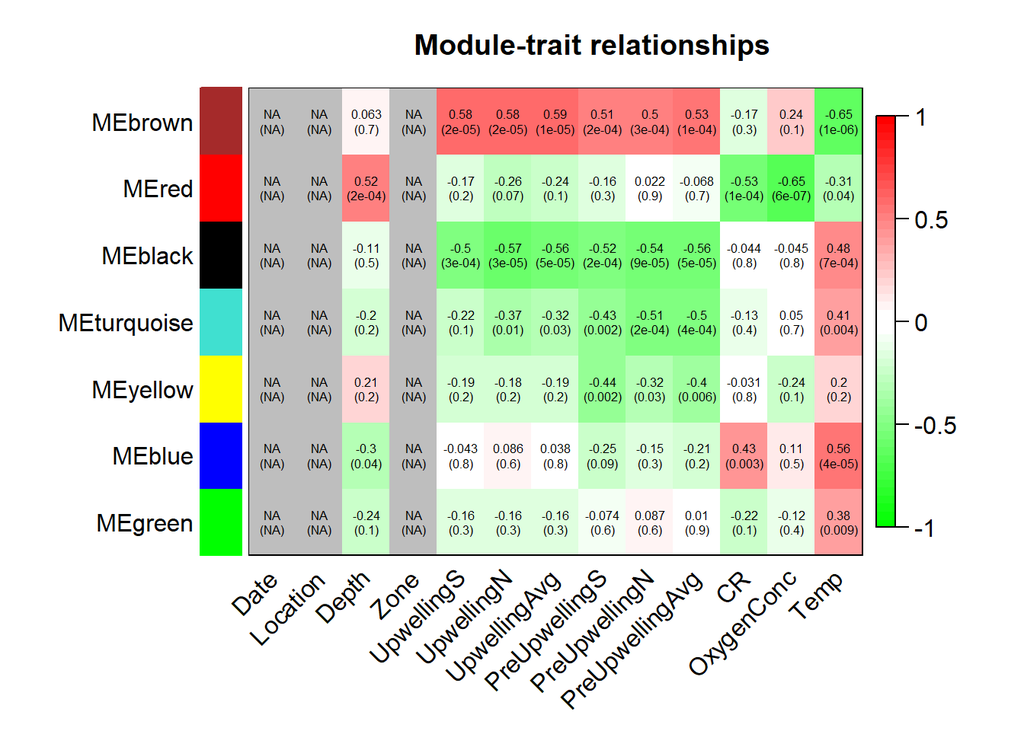

```r
moduleTraitPvalue = corPvalueStudent(moduleTraitCor, nSamples);

## Now visualize it:

## Will display correlations and their p-values
textMatrix = paste(signif(moduleTraitCor, 2), "\n(",
                   signif(moduleTraitPvalue, 1), ")", sep = "");
dim(textMatrix) = dim(moduleTraitCor)
par(mar = c(6, 8.5, 3, 3));

## Display the correlation values within a heatmap plot
labeledHeatmap(Matrix = moduleTraitCor,
               xLabels = names(datTraits),
               yLabels = names(MEs),
               ySymbols = names(MEs),
               colorLabels = FALSE,
               colors = greenWhiteRed(50),
               textMatrix = textMatrix,
               setStdMargins = FALSE,
               cex.text = 0.5,
               zlim = c(-1,1),
               main = paste("Module-trait relationships"))
```

Each row corresponds to a module eigengene, column to an Environmental trait. Each cell contains the corresponding Pearson correlation coefficient (top number) and p-vlaue (in parentheses). Table is color-coded by correlation according to the color legend.

#### 0.3.3.2 Quantify associations of individual taxa with our trait of interest

Have to look at previous step to figure out what color modules correlate significantly with certain traits

Define variable we are interested in from datTrait

```r
CR = as.data.frame(datTraits$CR);
names(CR) = "CR"

## names (colors) of the modules
modNames = substring(names(MEs), 3)

# get correlation between otus and eigenotus
TaxaModuleMembership = as.data.frame(cor(datExpr0, MEs, use = "p")); # use p = type of missing values handling
MMPvalue = as.data.frame(corPvalueStudent(as.matrix(TaxaModuleMembership), nSamples));
names(TaxaModuleMembership) = paste("MM", modNames, sep="");
names(MMPvalue) = paste("p.MM", modNames, sep="");

# get correlation between otus and trait
TaxaTraitSignificance = as.data.frame(cor(datExpr0, CR, use = "p"));
GSPvalue = as.data.frame(corPvalueStudent(as.matrix(TaxaTraitSignificance), nSamples));
names(TaxaTraitSignificance) = paste("GS.", names(CR), sep="");
names(GSPvalue) = paste("p.GS.", names(CR), sep="");
```

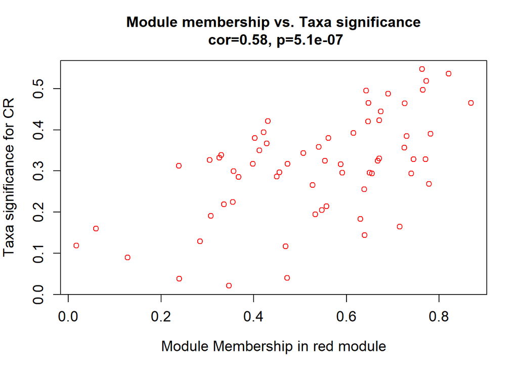

```r
module = "red"
column = match(module, modNames);
moduleTaxa = moduleColors==module;
par(mfrow = c(1,1));
verboseScatterplot(abs(TaxaModuleMembership[moduleTaxa, column]),
                   abs(TaxaTraitSignificance[moduleTaxa, 1]),
                   xlab = paste("Module Membership in", module, "module"),
                   ylab = "Taxa significance for CR",
                   main = paste("Module membership vs. Taxa significance\n"),
                   cex.main = 1.2, cex.lab = 1.2, cex.axis = 1.2, col = module)
```

This graph shows you each taxa that made it into the “red” module and how each taxa correlated with 1) the Environmental trait of interest and 2) how important it is to the module

The taxa/OTUs that have high module membership tend to occur whenever the module is represented in the environment and are therefore often connected throughout the samples with other red taxa/OTUs

Merge the statistical info from previous section (modules with high assocation with trait of interest–e.g. CR or Temp) with taxa annotation and write a file that summarizes these results

```r
names(datExpr0)
```

```
##   [1] "Otu00001" "Otu00002" "Otu00003" "Otu00004" "Otu00005" "Otu00006"
##   [7] "Otu00007" "Otu00008" "Otu00009" "Otu00010" "Otu00011" "Otu00012"
##  [13] "Otu00013" "Otu00014" "Otu00015" "Otu00016" "Otu00017" "Otu00018"
##  [19] "Otu00019" "Otu00020" "Otu00021" "Otu00022" "Otu00023" "Otu00024"
##  [25] "Otu00025" "Otu00026" "Otu00027" "Otu00028" "Otu00029" "Otu00030"
##  [31] "Otu00031" "Otu00032" "Otu00033" "Otu00034" "Otu00035" "Otu00036"
##  [37] "Otu00037" "Otu00038" "Otu00039" "Otu00040" "Otu00041" "Otu00042"
##  [43] "Otu00043" "Otu00044" "Otu00045" "Otu00046" "Otu00047" "Otu00048"
##  [49] "Otu00049" "Otu00050" "Otu00051" "Otu00052" "Otu00053" "Otu00054"
##  [55] "Otu00055" "Otu00056" "Otu00057" "Otu00058" "Otu00059" "Otu00060"
##  [61] "Otu00061" "Otu00062" "Otu00063" "Otu00064" "Otu00065" "Otu00066"
##  [67] "Otu00067" "Otu00068" "Otu00069" "Otu00070" "Otu00071" "Otu00072"
##  [73] "Otu00073" "Otu00074" "Otu00075" "Otu00076" "Otu00077" "Otu00078"
##  [79] "Otu00079" "Otu00080" "Otu00081" "Otu00082" "Otu00083" "Otu00084"
##  [85] "Otu00085" "Otu00086" "Otu00087" "Otu00088" "Otu00089" "Otu00090"
```

[output cut: 110 more lines]

```r
names(datExpr0)[moduleColors=="red"]
```

```
##  [1] "Otu00020" "Otu00031" "Otu00066" "Otu00070" "Otu00072" "Otu00073"
##  [7] "Otu00089" "Otu00106" "Otu00107" "Otu00114" "Otu00129" "Otu00139"
## [13] "Otu00155" "Otu00160" "Otu00186" "Otu00197" "Otu00200" "Otu00219"
## [19] "Otu00268" "Otu00271" "Otu00286" "Otu00287" "Otu00290" "Otu00296"
## [25] "Otu00316" "Otu00317" "Otu00326" "Otu00332" "Otu00343" "Otu00354"
## [31] "Otu00355" "Otu00369" "Otu00385" "Otu00399" "Otu00421" "Otu00430"
## [37] "Otu00447" "Otu00491" "Otu00498" "Otu00499" "Otu00501" "Otu00502"
## [43] "Otu00521" "Otu00568" "Otu00591" "Otu00593" "Otu00599" "Otu00605"
## [49] "Otu00653" "Otu00655" "Otu00663" "Otu00672" "Otu00673" "Otu00688"
## [55] "Otu00692" "Otu00698" "Otu00716" "Otu00724" "Otu00728" "Otu00733"
## [61] "Otu00736" "Otu00738" "Otu00741" "Otu00750"
```

```r
## Need to figure out proper file for TaxaAnnotation
#annot = read.table("MB.subsample.fn.0.03.cons.taxonomy",header=T,sep="\t");
#dim(annot)
#names(annot)
#probes = names(datExpr0)
#probes2annot = match(probes, annot$OTU)

## The following is the number or probes without annotation:
#sum(is.na(probes2annot))
## Should return 0.
```

```r
##################################################################################
#
# ## Create the starting data frame
# TaxaInfo0 = data.frame(Taxon = probes,
#                        TaxaSymbol = annot$OTU[probes2annot],
#                        LinkID = annot$Taxonomy[probes2annot],
#                        moduleColor = moduleColors,
#                        TaxaTraitSignificance,
#                        GSPvalue)
#
# ## Order modules by their significance for our environmental trait of interest
# modOrder = order(-abs(cor(MEs, CR, use = "p")));
#
# ## Add module membership information in the chosen order
# for (mod in 1:ncol(TaxaModuleMembership))
# {
#   oldNames = names(TaxaInfo0)
#   TaxaInfo0 = data.frame(TaxaInfo0, TaxaModuleMembership[, modOrder[mod]],
#                          MMPvalue[, modOrder[mod]]);
#   names(TaxaInfo0) = c(oldNames, paste("MM.", modNames[modOrder[mod]], sep=""),
#                        paste("p.MM.", modNames[modOrder[mod]], sep=""))
# }
#
# ## Order the OTUs in the geneInfo variable first by module color, then by geneTraitSignificance
# TaxaOrder = order(TaxaInfo0$moduleColor, -abs(TaxaInfo0$GS.CR));
# TaxaInfo = TaxaInfo0[TaxaOrder, ]
#
# ##################################################################################
#
# ## Write file
#
# write.csv(TaxaInfo, file = "TaxaInfo.csv")
#
```

Definitions

- moduleColor is the module that the OTU was ultimately put into
- GS stands for Gene Significance (for us it means taxon significance) while MM stands for module membership.
- GS.Environmentaltrait = Pearson Correlation Coefficient for that OTU with the trait. GS allows incorporation of external info into the co-expression network by showing gene/OTU significance. The higher the absolute value of GS the more biologically significant the gene (or in our case taxa) to that external variable (e.g. CR).
- p.GS.Environmentaltrait = P value for the preceding relationship.
- MM.color = Pearson Correlation Coefficient for Module Membership–i.e. how well that OTU correlates with that particular color module (each OTU has a value for each module but only belongs to one module). If close to 0 or negative then the taxa is not part of that color module (since each OTU has to be put in a module you may get some OTUs that are close to 0, but they aren’t important to that module). If it is close to 1 then it is highly connected to that color module, but will be placed with the color module that it is most connected to throughout the samples.
- p.MM.color = P value for the preceding relationship.

Modules will be ordered by their significance for the external variable you selected (e.g. CR), with the most significant ones to the left.

Each of the modules (with each OTU assigned to exactly one module) will be represented for the environmental trait you selected.

You will have to rerun this for each environmental trait you are interested in.

### 0.3.4 Visualizing the OTU/taxa network

```r
nOTU = ncol(datExpr0)
nSamples = nrow(datExpr0)

## Calculate topological overlap anew: this could be done more efficiently by saving the TOM
## calculated during module detection, but let us do it again here.
dissTOM = 1-TOMsimilarityFromExpr(datExpr0, power = 10, networkType = "signed");
```

```
## TOM calculation: adjacency..
## ..will not use multithreading.
##  Fraction of slow calculations: 0.000000
## ..connectivity..
## ..matrix multiplication (system BLAS)..
## ..normalization..
## ..done.
```

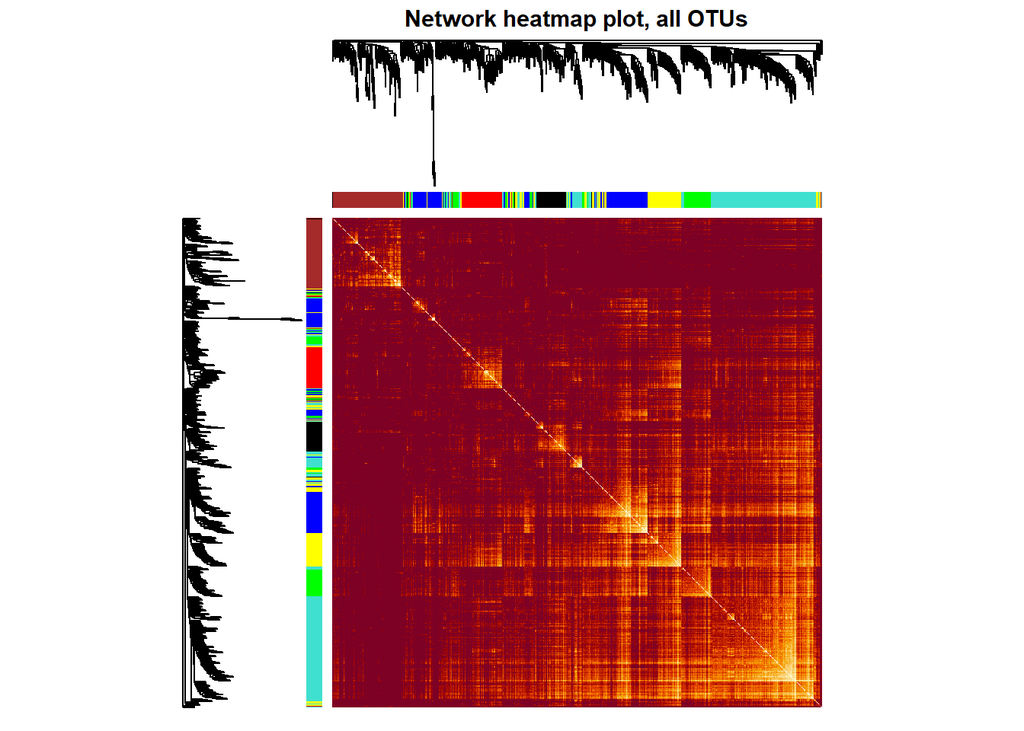

```r
## Transform dissTOM with a power to make moderately strong connections more visible in the heatmap
plotTOM = dissTOM^10;

## Set diagonal to NA for a nicer plot
diag(plotTOM) = NA;

## Call the plot function
TOMplot(plotTOM, TaxaTree, moduleColors, main = "Network heatmap plot, all OTUs")
```

Still have to do first few steps from above (dissTOM creation)

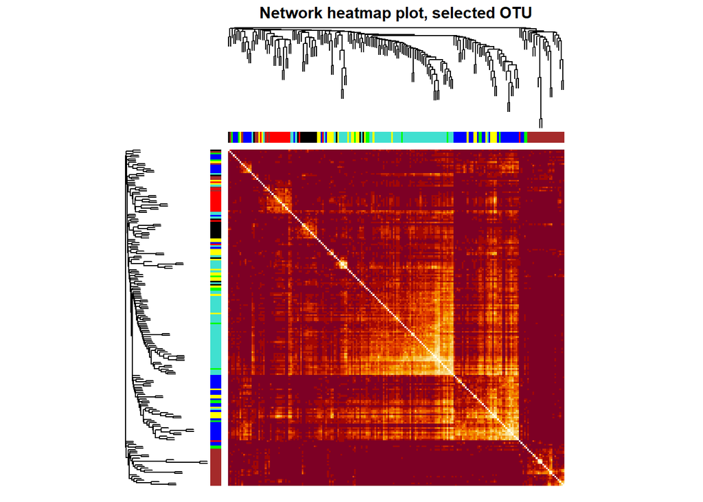

```r
nSelect = 200

## For reproducibility, we set the random seed
set.seed(10);
select = sample(nOTU, size = nSelect);
selectTOM = dissTOM[select, select];

## There's no simple way of restricting a clustering tree to a subset of OTU, so we must re-cluster.
selectTree = hclust(as.dist(selectTOM), method = "average")
selectColors = moduleColors[select];


## Taking the dissimilarity to a power, say 10, makes the plot more informative by effectively changing
## the color palette; setting the diagonal to NA also improves the clarity of the plot
plotDiss = selectTOM^10;
diag(plotDiss) = NA;
TOMplot(plotDiss, selectTree, selectColors, main = "Network heatmap plot, selected OTU")
```